# Clase 7 - Workshop del proyecto integrador

Carolina Pradier y Laia Domenech Burin

14 marzo, 2023

```r
library(tidyverse)
library(readr)
options(scipen = 9999)
options(dplyr.summarise.inform = FALSE)
```

# Introducción

En esta clase les proponemos algunas herramientas para abordar su proyecto integrador (y otros proyectos futuros).

En particular, les traemos algunas **bases de datos** que pueden resultarles útiles a la hora de estudiar diversas aristas de las problemáticas de género.

# La comunidad de R, ¿qué hacemos cuando el código no corre?

Existe una gran comunidad de usuarios de R, que podrían ayudarnos cuando nos enfrentamos a alguna dificultad.

En general, si un código no funciona, es útil *googlear* nuestro error (probablemente no seamos la primera persona en haber encontrado esta dificultad), así como también recurrir a la *ayuda de R* para chequear el funcionamiento de las funciones y los paquetes que estamos usando.

También podemos tejer redes con usuarios y usuarios dispuestes a darnos una mano, por ejemplo:

- R-Ladies Buenos Aires: https://www.meetup.com/es-ES/rladies-buenos-aires/?_cookie-check=RaPc633BUjPoa2Ty

# ENGHo

El INDEC realizó la Encuesta Nacional de Gastos de los Hogares 2017-2018 (ENGHo 2017-2018) con el objetivo principal de obtener información acerca de los gastos y los ingresos de los hogares y sus características sociodemográficas. La encuesta, llevada a cabo entre noviembre de 2017 y noviembre de 2018, permite caracterizar las condiciones de vida de los hogares, fundamentalmente en términos de su acceso a los bienes y servicios, y de los ingresos –monetarios o en especie–.

## Artículos

La base de artículos contiene la descripción de los productos y las divisiones, los grupos, las clases y las subclases que los contienen (en la base de gastos aparece el código, no la descripción).

```r
articulos <- read.table(file ="./engho/engho2018_articulos.txt",sep="|", dec=".", header = TRUE, fill = TRUE,fileEncoding = "UTF-8")

#por ejemplo, para ver los articulos que están relacionados a Salud

articulos %>%
  filter(division_desc == 'SALUD') %>% select(articulo_desc,grupo_desc,clase_desc,subclase_desc,division_desc) %>%
  head(.,10)
```

```
##                  articulo_desc                              grupo_desc
## 1                      Alergia PRODUCTOS, ARTEFACTOS Y EQUIPOS MÉDICOS
## 2  Antibióticos y antisépticos PRODUCTOS, ARTEFACTOS Y EQUIPOS MÉDICOS
## 3              Anticonceptivos PRODUCTOS, ARTEFACTOS Y EQUIPOS MÉDICOS
## 4            Antiinflamatorios PRODUCTOS, ARTEFACTOS Y EQUIPOS MÉDICOS
## 5                    Cardíacos PRODUCTOS, ARTEFACTOS Y EQUIPOS MÉDICOS
## 6               Dermatológicos PRODUCTOS, ARTEFACTOS Y EQUIPOS MÉDICOS
## 7                     Diabetes PRODUCTOS, ARTEFACTOS Y EQUIPOS MÉDICOS
## 8                      Diarrea PRODUCTOS, ARTEFACTOS Y EQUIPOS MÉDICOS
## 9                   Digestivos PRODUCTOS, ARTEFACTOS Y EQUIPOS MÉDICOS
## 10              Fiebre o dolor PRODUCTOS, ARTEFACTOS Y EQUIPOS MÉDICOS
##                 clase_desc           subclase_desc division_desc
## 1  Productos farmacéuticos Productos farmacéuticos         SALUD
## 2  Productos farmacéuticos Productos farmacéuticos         SALUD
## 3  Productos farmacéuticos Productos farmacéuticos         SALUD
## 4  Productos farmacéuticos Productos farmacéuticos         SALUD
## 5  Productos farmacéuticos Productos farmacéuticos         SALUD
## 6  Productos farmacéuticos Productos farmacéuticos         SALUD
## 7  Productos farmacéuticos Productos farmacéuticos         SALUD
## 8  Productos farmacéuticos Productos farmacéuticos         SALUD
## 9  Productos farmacéuticos Productos farmacéuticos         SALUD
## 10 Productos farmacéuticos Productos farmacéuticos         SALUD
```

## Personas, hogares y gastos

Las bases se conectan entre si la variable id (identifica hogar) y miembro (identifica a personas dentro de un hogar), por lo tanto, se unen las bases de personas, hogares y gastos usando estas variables.

¿Qué información contiene cada columna? Ver diseño de registro!

```r
#un registro por cada artículo adquirido por el hogar y sus miembros
gastos <- read.table(file ="./engho/engho2018_gastos.txt",sep="|", dec=".", header = TRUE, fill = TRUE)

#names(gastos)

#head(gastos,10)
```

```r
#un registro por hogar: cada hogar se identifica usando "id"
hogares <- read.table(file ="./engho/engho2018_hogares.txt",sep="|", dec=".", header = TRUE, fill = TRUE)

#names(hogares)

#head(hogares,10)
```

```r
#un registro por persona: cada persona se identifica usando "id" y "miembro"
personas <- read.table(file ="./engho/engho2018_personas.txt",sep="|", dec=".", header = TRUE, fill = TRUE)

#names(personas)

#head(personas,10)
```

```r
base_integrada <- gastos %>%
  left_join(.,hogares, by = "id") %>%
  left_join(.,personas, by = c("id","miembro"))


#ojo! hay variables duplicadas en las bases: ver aquellas que quedan con nombres .x, .y
#para que no nos pase, seleccionar sólo las variables relevantes para nuestro análisis y hacer el join, generando una base más chica con las variables que nos interesan para el análisis

#names(base_integrada)
```

## Ejemplo de procesamiento

¿Quién gasta más en productos de gestión menstrual?

Recurro al código de artículo de cada uno de estos productos. Además, como siempre en una encuesta, aplico el ponderador (pondera) para obtener estadísticas descriptivas que representen a la población total.

```r
gasto_deciles <- base_integrada %>%
   group_by(dinth_t) %>% #decil de ingreso total del hogar
    summarise(gasto_gestion_menstrual = weighted.mean(monto[articulo == 'A1213108'], pondera.x[articulo == 'A1213108'],na.rm=T))


gasto_deciles
```

```
## # A tibble: 10 × 2
##    dinth_t gasto_gestion_menstrual
##      <int>                   <dbl>
##  1       1                    169.
##  2       2                    187.
##  3       3                    197.
##  4       4                    177.
##  5       5                    294.
##  6       6                    265.
##  7       7                    312.
##  8       8                    340.
##  9       9                    336.
## 10      10                    422.
```

Podemos observar a partir de este procesamiento que el gasto en productos de gestión menstrual crece con los ingresos del hogar ¿Cómo podemos interpretar esto? Se trata de un gasto que se ajusta en los hogares con mayores carencias económicas (a pesar de que las personas que menstrúan necesitan estos productos independientemente de su situación socioeconómica).

¿Y si refinamos el análisis para estudiar el gasto dividido por la cantidad de miembros mujeres?

Creamos la variables a partir de la base personas:

```r
variable_cantidad_mujeres <- personas %>%
  mutate(sexo = case_when(cp13==1~"Varones",
                          cp13==2~"Mujeres")) %>%
  group_by(id,sexo) %>%
  summarise(miembros_sexo =n()) %>%
  ungroup() %>%
  filter(sexo == "Mujeres") %>%
  select(id, "cantidad_mujeres" = miembros_sexo) %>%
  unique()

head(variable_cantidad_mujeres,10)
```

```
## # A tibble: 10 × 2
##        id cantidad_mujeres
##     <int>            <int>
##  1   8558                2
##  2  60568                1
##  3 146001                1
##  4 271514                1
##  5 290257                2
##  6 347750                3
##  7 360929                1
##  8 375875                1
##  9 486282                3
## 10 522357                3
```

La incorporamos a nuestra base de datos:

```r
base_integrada <- base_integrada %>%
  left_join(.,variable_cantidad_mujeres, by = "id")
```

Recalculamos

```r
gasto_deciles_pc <- base_integrada %>%
   group_by(dinth_t) %>% #decil de ingreso total del hogar
    summarise(gasto_gestion_menstrual_pc = weighted.mean((monto[articulo == 'A1213108']/cantidad_mujeres[articulo == 'A1213108']), pondera.x[articulo == 'A1213108'],na.rm=T))

gasto_deciles_pc
```

```
## # A tibble: 10 × 2
##    dinth_t gasto_gestion_menstrual_pc
##      <int>                      <dbl>
##  1       1                       126.
##  2       2                       110.
##  3       3                       142.
##  4       4                       115.
##  5       5                       176.
##  6       6                       166.
##  7       7                       199.
##  8       8                       180.
##  9       9                       196.
## 10      10                       268.
```

¿Cómo se modificaron nuestros resultados? Vamos a visualizar

```r
tabla_resultados <- gasto_deciles %>%
  left_join(.,gasto_deciles_pc, by ="dinth_t") %>%
  pivot_longer(!dinth_t, names_to = "indicador", values_to = "valor")

tabla_resultados$indicador[tabla_resultados$indicador == "gasto_gestion_menstrual"] <- "Total"
tabla_resultados$indicador[tabla_resultados$indicador == "gasto_gestion_menstrual_pc"] <- "Por miembro de sexo femenino"

tabla_resultados
```

```
## # A tibble: 20 × 3
##    dinth_t indicador                    valor
##      <int> <chr>                        <dbl>
##  1       1 Total                         169.
##  2       1 Por miembro de sexo femenino  126.
##  3       2 Total                         187.
##  4       2 Por miembro de sexo femenino  110.
##  5       3 Total                         197.
##  6       3 Por miembro de sexo femenino  142.
##  7       4 Total                         177.
##  8       4 Por miembro de sexo femenino  115.
##  9       5 Total                         294.
## 10       5 Por miembro de sexo femenino  176.
## 11       6 Total                         265.
## 12       6 Por miembro de sexo femenino  166.
## 13       7 Total                         312.
## 14       7 Por miembro de sexo femenino  199.
## 15       8 Total                         340.
## 16       8 Por miembro de sexo femenino  180.
## 17       9 Total                         336.
## 18       9 Por miembro de sexo femenino  196.
## 19      10 Total                         422.
## 20      10 Por miembro de sexo femenino  268.
```

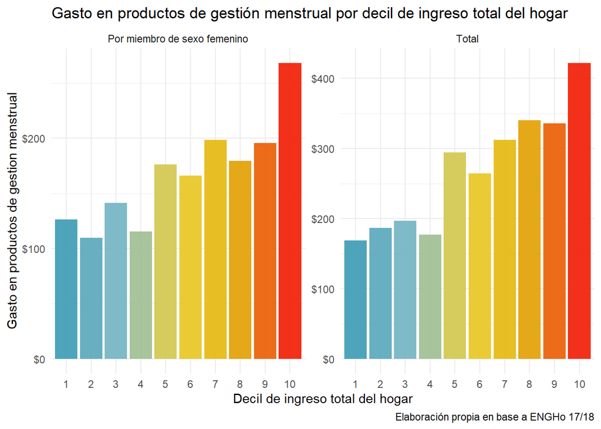

```r
library(wesanderson)

ggplot(tabla_resultados,aes(y = valor, x = factor(dinth_t),
        fill = dinth_t  )
        )+
  geom_col(alpha = 0.9)+
  theme_minimal()+
  labs(title = 'Gasto en productos de gestión menstrual por decil de ingreso total del hogar',
       x="Decil de ingreso total del hogar",y="Gasto en productos de gestion menstrual",
       caption = "Elaboración propia en base a ENGHo 17/18")+
  facet_wrap(~indicador,scales = "free")+
  scale_y_continuous(labels = function(x) paste0("$",x))+
  scale_fill_gradientn(colours = wes_palette("Zissou1", 100, type = "continuous")) +
  guides(fill = "none")
```

# EANNA

La EANNA es una encuesta realizada por el Ministerio de Trabajo, Empleo y Seguridad Social, cuyo objetivo es proporcionar información estadística sobre los niños, niñas y adolescentes de 5 a 17 años de edad involucrados en actividades económicas y no económicas. La encuesta especifica en características demográficas, educativas y socioeconómicas generales de los hogares de pertenencia, pormenorizando los rasgos distintivos del trabajo infantil y las principales razones que sustentan el fenómeno.

```r
eanna_urb <- read_delim("./EANNA/EANNA_urbana.csv")
```

Un análisis que podemos realizar a partir de ella es acerca de las distinciones en el abandono escolar y tipos de trabajo realizado, según género. Para ello, podemos ver cuáles son las preguntas que nos interesan para el análisis [en el manual de uso de la base de datos](https://www.indec.gob.ar/ftp/cuadros/menusuperior/eanna/eanna_urbana_manual_bases.pdf). Esta es una práctica que tenemos que incorporar siempre que trabajemos con bases de datos nuevas.

Podemos destacar algunas variables de interés:

- `C2_P03` que define el sexo
- `C2_P02` tiene la edad
- `C3_E01` si asiste actualmente a la escuela/jardín
- `C3_E16` edad de abandono escolar
- `C3_E17_01:C3_E17_13` múltiples motivos de abandono escolar
- `Diagvenn` indica la combinación de actividades realizadas
- `PONDERA` como ponderador de las filas

Vamos a filtrar estas variables de interés y recodificar algunas de ellas con las que empezaremos a trabajar.

```r
eanna_urb <- eanna_urb %>% select(sexo = C2_P03, edad = C2_P02, asist_escolar = C3_E01,
                                  ult_anio = C3_E16, actividades =Diagvenn, C3_E17_01:C3_E17_13, PONDERA)

eanna_urb <- eanna_urb %>% mutate(sexo = case_when(
  sexo == 1 ~ "Varón",
  sexo == 2 ~ "Mujer"
))

eanna_urb <- eanna_urb %>% mutate(asist_escolar = case_when(
  asist_escolar == 1 ~ "Sí",
  asist_escolar == 2 ~ "No",
  asist_escolar == 9 ~ "Sin datos"
))

eanna_urb <- eanna_urb %>% mutate(actividades = case_when(
  actividades == 1 ~ "Solo trabaja",
  actividades == 2 ~ "Solo realiza actividad para el autoconsumo",
  actividades == 3 ~ "Solo realiza actividad doméstica ",
  actividades == 4 ~ "Trabaja y realiza autoconsumo",
  actividades == 5 ~ "Trabaja y actividad doméstica",
  actividades == 6 ~ "Realiza autoconsumo y doméstica" ,
  actividades == 7 ~ "Trabaja, autoconsumo y doméstica",
  actividades == 8 ~ "No trabaja"
))
```

Ahora, exploremos un poco la base. ¿Cómo es la composición por sexo de los encuestados?

Recuerden que tenemos una variable ponderadora llamada `PONDERA`, así que vamos a hacer la suma sobre esa columna.

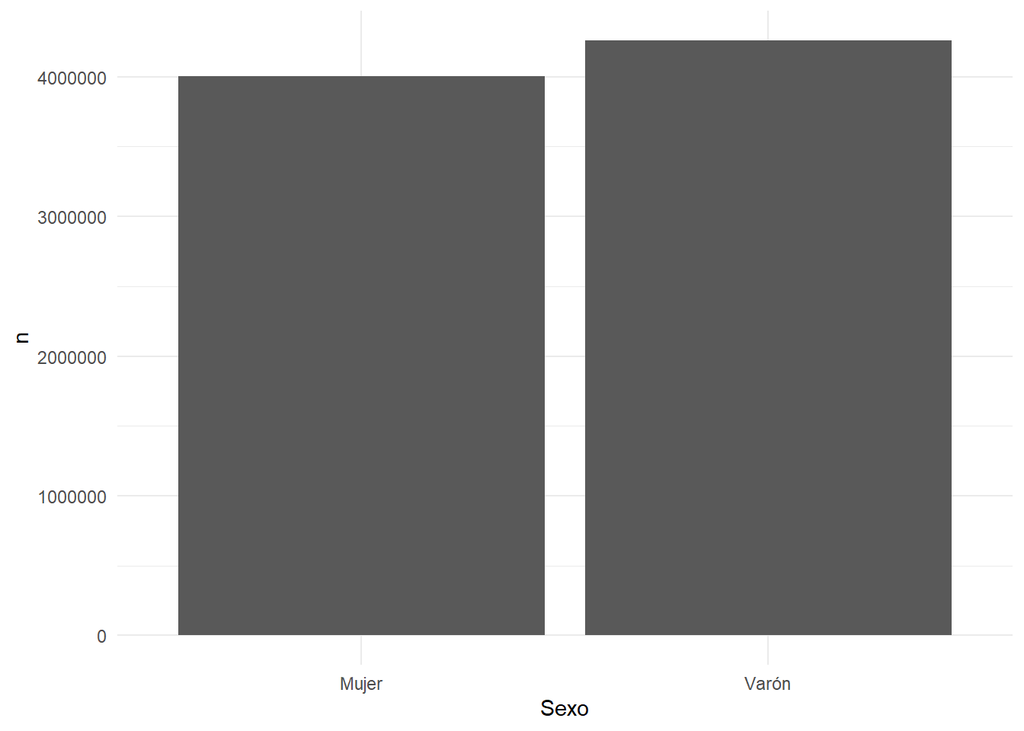

```r
sexo_cont <- eanna_urb %>%
  group_by(sexo) %>%
  summarise(n_pond = sum(PONDERA))

sexo_cont %>%
  ggplot(aes(x=sexo, y = n_pond))+
  geom_col() +
  labs(x = "Sexo",
       y = "n")+
  theme_minimal()
```

Tenemos 4 millones de niñes para cada sexo, y las clases se encuentran bastante balanceadas. ¿Qué tal las edades?

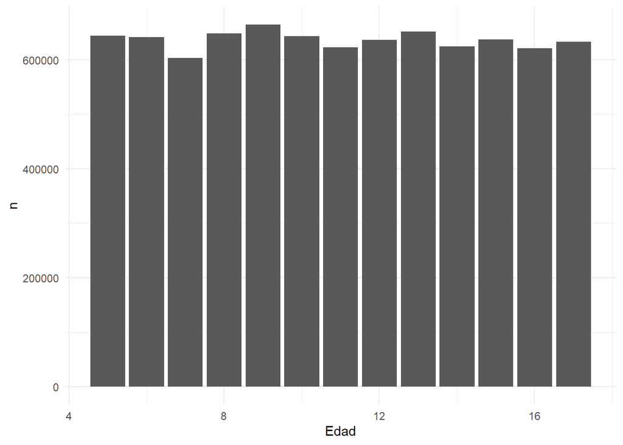

```r
edad_cont <- eanna_urb %>%
  group_by(edad) %>%
  summarise(n_pond = sum(PONDERA))

edad_cont %>%
  ggplot(aes(x=edad, y = n_pond))+
  geom_col() +
  labs(x = "Edad",
       y = "n")+
  theme_minimal()
```

Las edades también parecen estar bastante balanceadas. Tenemos unos 600.000 casos en cada una de las categorías.

Ahora, ¿cómo se distribuye la asistencia escolar según sexo? Podemos verlo con un conteo y un gráfico de barras.

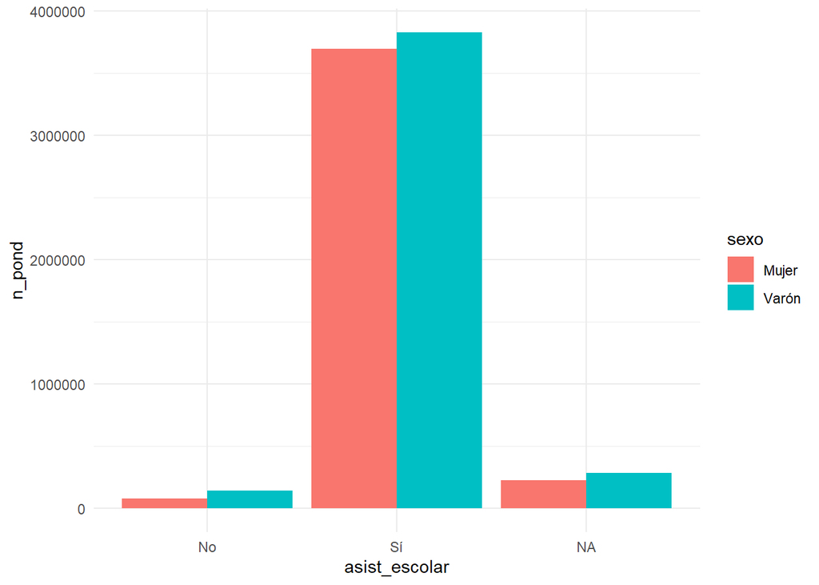

```r
sexo_escolariz <- eanna_urb %>% group_by(sexo, asist_escolar) %>%
                    summarise(n_pond=sum(PONDERA))

sexo_escolariz %>%
  ggplot(aes(x=asist_escolar, y = n_pond, fill = sexo))+
  geom_col(position = 'dodge') +
  theme_minimal()
```

¡Ups! Tenemos varios casos sin datos que nos generan una barra de NA’s. Vamos a borrarlos filtrando antes de hacer el gráfico.

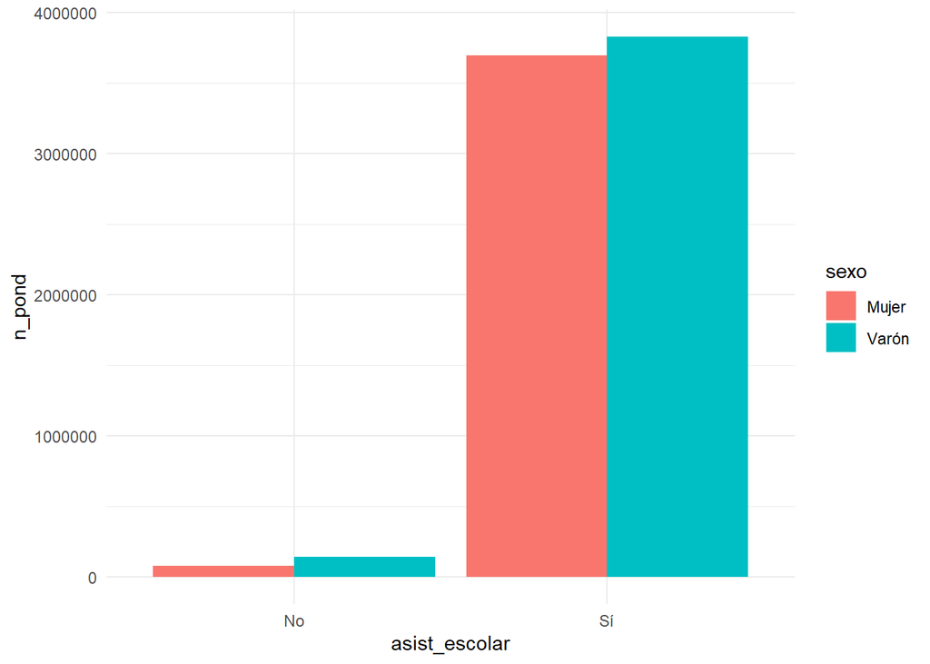

```r
sexo_escolariz <- sexo_escolariz %>% filter(!is.na(asist_escolar))

sexo_escolariz %>%
  ggplot(aes(x=asist_escolar, y = n_pond, fill = sexo))+
  geom_col(position = 'dodge') +
  theme_minimal()
```

Por suerte, la gran mayoría de les niñes asisten a la escuela. Pero, ¿qué pasa con ese pequeño porcentaje que no asiste? Si bien la escala es bastante pequeña, parece que la cantidad de varones que no asisten al colegio duplica la de mujeres. Veamos cómo se vería este gráfico si hacemos que los valores de la escala crezcan en raíces cuadradas, con `scale_y_sqrt()`.

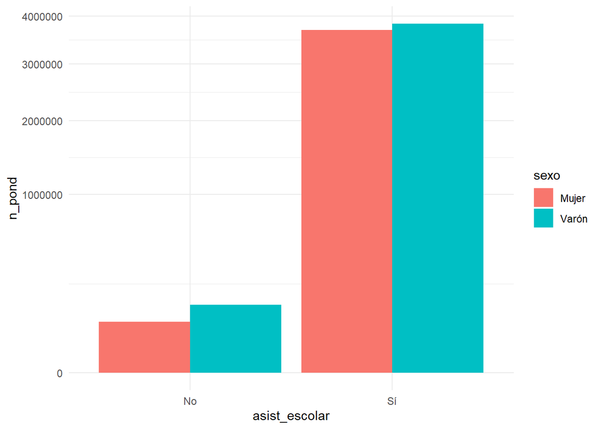

```r
sexo_escolariz %>%
  ggplot(aes(x=asist_escolar, y = n_pond, fill = sexo))+
  geom_col(position = 'dodge') +
  scale_y_sqrt()+
  theme_minimal()
```

Podemos ver que si bien menos mujeres abandonan el colegio en relación a los varones, no está la brecha que vimos más arriba.

Adentrémonos en esta sub-muestra. Vamos a filtrar los casos de niñes que no asisten a la escuela o el jardín.

```r
no_escolaridad <- eanna_urb %>% filter(asist_escolar == "No")

ne_sexo <- no_escolaridad %>% group_by(sexo) %>%
  summarise(n_pond = sum(PONDERA))

ne_sexo
```

```
## # A tibble: 2 × 2
##   sexo  n_pond
##   <chr>  <dbl>
## 1 Mujer  81972
## 2 Varón 146178
```

Tenemos más de 81000 niñas que no asisten al colegio contra 146178 niños que no lo hacen, de manera que tenemos un total de 228150 niñes que no asisten al colegio.

¿Cómo se distribuyen las edades al interior de este grupo?

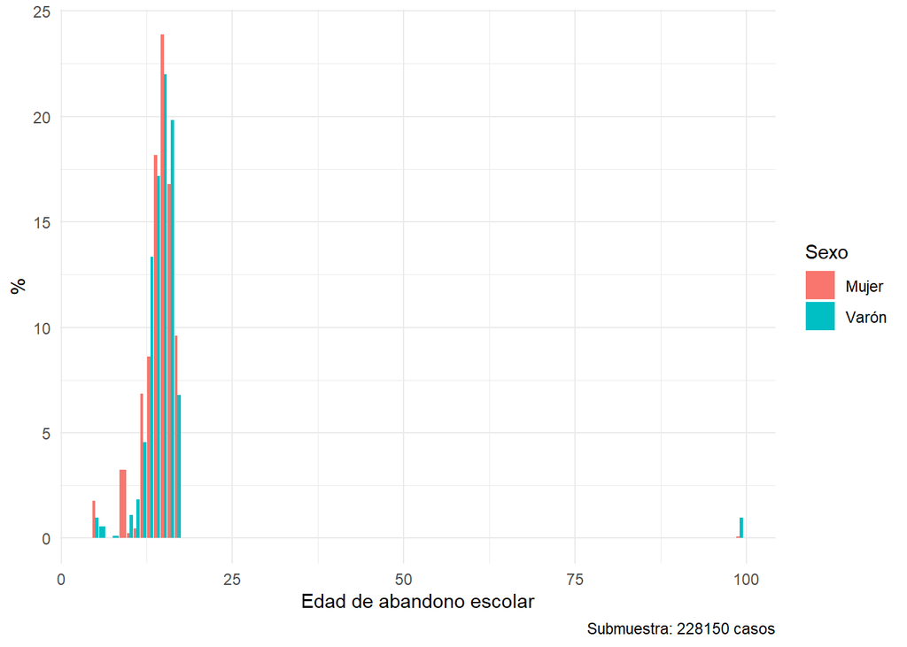

```r
ne_edades_sexo <- no_escolaridad %>%
  group_by(sexo, ult_anio) %>%
  summarise(n=sum(PONDERA))%>%
  mutate(ult_anio = as.numeric(ult_anio)) %>%
  group_by(sexo)%>%
  mutate(perc = n/sum(n)*100)

ne_edades_sexo %>%
  ggplot(aes(x=as.numeric(ult_anio), y = perc, fill = sexo))+
  geom_col(position = 'dodge') +
  labs(x = "Edad de abandono escolar",
       y = "%",
       fill = "Sexo",
       caption = paste0("Submuestra: ", sum(ne_sexo$n_pond), " casos"))+
  theme_minimal()
```

Como la forma de registrar los NA en esta variable es con el número 99, los ejes nos quedan bastante deformados. Por eso, vamos a recortar el eje x entre las edades de les encuestades: 5 y 17.

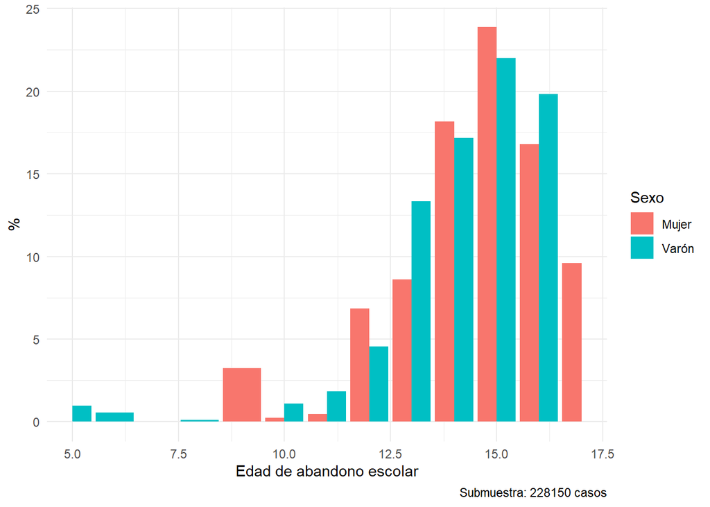

```r
ne_edades_sexo %>%
  ggplot(aes(x=as.numeric(ult_anio), y = perc, fill = sexo))+
  geom_col(position = 'dodge') +
  xlim(5, 17)+
  labs(x = "Edad de abandono escolar",
       y = "%",
       fill = "Sexo",
       caption = paste0("Submuestra: ", sum(ne_sexo$n_pond), " casos"))+
  theme_minimal()
```

Vemos que de manera indistinta al género, la mayoría de les niñes que abandonan el colegio lo hacen entre los 14 y los 16 años. Ahora, ¿por qué motivos lo hacen?

Primero, creamos un objeto llamado `rtas_abandono` donde guardaremos la cantidad de varones y mujeres, y vamos a pivotear las columnas de interés.

```r
rtas_abandono <- no_escolaridad %>%
  group_by(sexo, PONDERA)%>%
#  mutate(n_pond=sum(PONDERA))%>%
  select(sexo, C3_E17_01:C3_E17_13, PONDERA) %>%
  pivot_longer(cols = -c(sexo, PONDERA), names_to = "motivo", values_to = "rta") %>%
  mutate(motivo = case_when(
      motivo == "C3_E17_01" | motivo == "C3_E17_03" | motivo == "C3_E17_08" | motivo == "C3_E17_11"~ "Desinterés/desaliento/dificultad",
      motivo == "C3_E17_02" | motivo == "C3_E17_04"  | motivo == "C3_E17_06" | motivo == "C3_E17_12" ~ "Problemas de oferta",
      motivo == "C3_E17_05" ~ "Problemas económicos",
      motivo == "C3_E17_07" ~ "Decisión de los padres",
      motivo == "C3_E17_09" | motivo == "C3_E17_13" ~ "Tareas de cuidado", #Tareas de cuidado
      motivo == "C3_E17_10" ~ "Necesitaba/quería trabajar"
          ))

rtas_abandono
```

```
## # A tibble: 6,201 × 4
## # Groups:   sexo, PONDERA [398]
##    sexo  PONDERA motivo                           rta
##    <chr>   <dbl> <chr>                            <chr>
##  1 Varón    1996 Desinterés/desaliento/dificultad 2
##  2 Varón    1996 Problemas de oferta              2
##  3 Varón    1996 Desinterés/desaliento/dificultad 2
##  4 Varón    1996 Problemas de oferta              2
##  5 Varón    1996 Problemas económicos             1
##  6 Varón    1996 Problemas de oferta              2
##  7 Varón    1996 Decisión de los padres           2
##  8 Varón    1996 Desinterés/desaliento/dificultad 1
##  9 Varón    1996 Tareas de cuidado                1
## 10 Varón    1996 Necesitaba/quería trabajar       1
## # … with 6,191 more rows
```

```r
rtas_abandono <- rtas_abandono %>% mutate(rta = case_when(
      rta == "1" ~ "Sí",
      rta == "2" ~ "No",
      TRUE ~ "NR"
    ))

head(rtas_abandono)
```

```
## # A tibble: 6 × 4
## # Groups:   sexo, PONDERA [1]
##   sexo  PONDERA motivo                           rta
##   <chr>   <dbl> <chr>                            <chr>
## 1 Varón    1996 Desinterés/desaliento/dificultad No
## 2 Varón    1996 Problemas de oferta              No
## 3 Varón    1996 Desinterés/desaliento/dificultad No
## 4 Varón    1996 Problemas de oferta              No
## 5 Varón    1996 Problemas económicos             Sí
## 6 Varón    1996 Problemas de oferta              No
```

Ahora, podemos ver la feminización de los motivos de abandono escolar. Es decir, podemos ver qué porcentaje personas que realizan esa actividad son mujeres, y qué porcentaje son varones.

```r
rtas_abandono <- rtas_abandono %>% filter(rta != "No" & rta != "NR") %>%
  group_by(sexo, motivo) %>%
  summarise(rtas = sum(PONDERA)) %>%
  ungroup()%>%
  group_by(motivo)%>%
  mutate(n_total = sum(rtas),
         perc = (rtas/n_total)*100)

rtas_abandono
```

```
## # A tibble: 12 × 5
## # Groups:   motivo [6]
##    sexo  motivo                            rtas n_total  perc
##    <chr> <chr>                            <dbl>   <dbl> <dbl>
##  1 Mujer Decisión de los padres            9062   24283  37.3
##  2 Mujer Desinterés/desaliento/dificultad 37307  111943  33.3
##  3 Mujer Necesitaba/quería trabajar        6103   44440  13.7
##  4 Mujer Problemas de oferta              17335   54153  32.0
##  5 Mujer Problemas económicos              8237   25806  31.9
##  6 Mujer Tareas de cuidado                27946   36473  76.6
##  7 Varón Decisión de los padres           15221   24283  62.7
##  8 Varón Desinterés/desaliento/dificultad 74636  111943  66.7
##  9 Varón Necesitaba/quería trabajar       38337   44440  86.3
## 10 Varón Problemas de oferta              36818   54153  68.0
## 11 Varón Problemas económicos             17569   25806  68.1
## 12 Varón Tareas de cuidado                 8527   36473  23.4
```

Ahora sí, lo podemos graficar:

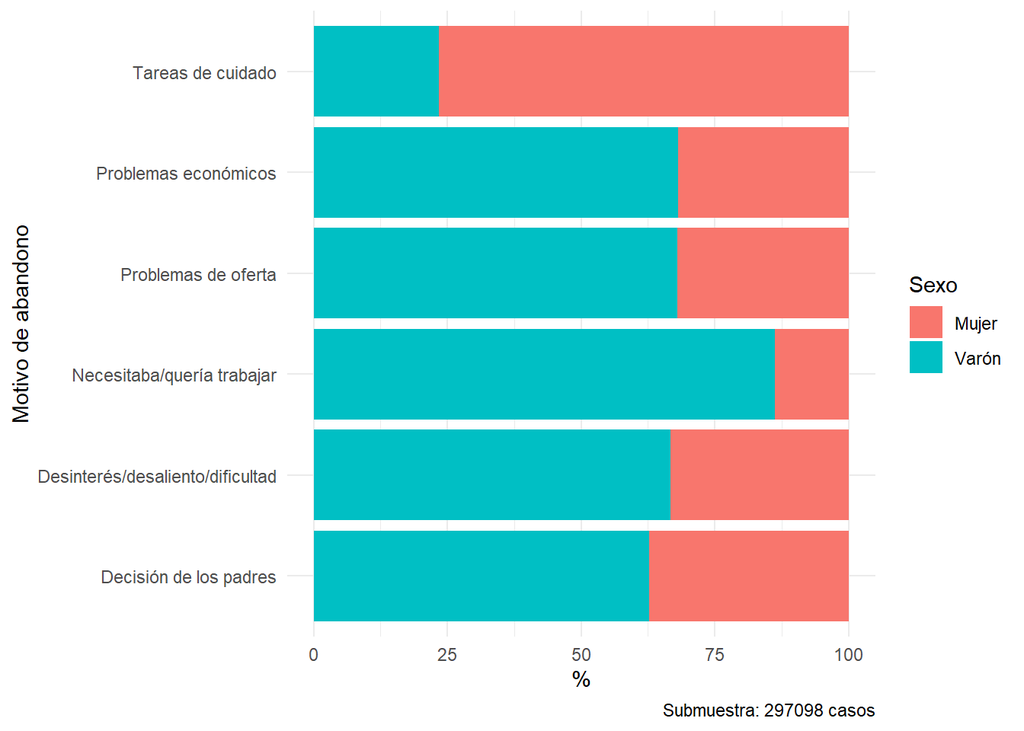

```r
rtas_abandono %>%
  ggplot(aes(x=motivo, y = perc, fill = sexo))+
  geom_col() +
  labs(x = "Motivo de abandono",
       y = "%",
       fill = "Sexo",
       caption = paste0("Submuestra: ", sum(rtas_abandono$rtas)," casos"))+
  coord_flip()+
  theme_minimal()
```

Podemos ver diferencias sustanciales entre el sexo asignado al nacer y los motivos de abandono escolar. En principio, los varones dejan en mucha mayor proporción el colegio para incorporarse al trabajo productivo, mientras que las mujeres lo hacen mucho más por tener que dedicarse a tareas de trabajo reproductivo.

¿Cómo se ve esto en las actividades que realizan estes niñes? Grafiquemos la distribución de la variable `actividad` entre los sexos

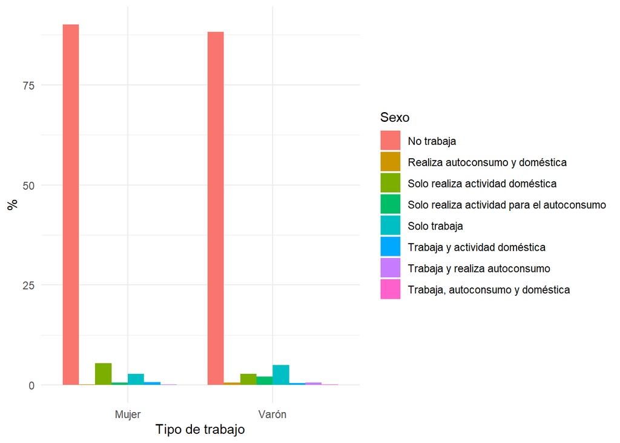

```r
eanna_urb %>% group_by(sexo, actividades) %>%
  summarize(n=sum(PONDERA))%>%
  mutate(perc = n/sum(n)*100)%>%
  ggplot(aes(x=sexo, y=perc, fill = actividades))+
  geom_col(position = 'dodge')+
  labs(x = "Tipo de trabajo",
       y = "%",
       fill = "Sexo")+
  theme_minimal()
```

Como (por suerte) la gran mayoría de les niñes no trabajan, o por lo menos no está registrado de manera formal, no podemos ver cómo se distribuyen los casos entre quienes sí realizan algún tipo de actividad económica. Vamos a filtrarlo para ver bien esta distinción.

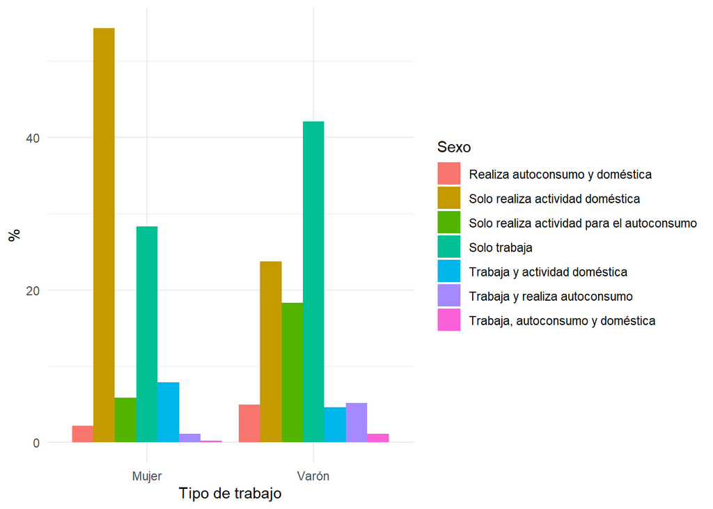

```r
eanna_urb %>% group_by(sexo, actividades) %>%
  summarize(n=sum(PONDERA))%>%
  filter(actividades != "No trabaja")%>%
  mutate(perc = n/sum(n)*100)%>%
  ggplot(aes(x=sexo, y=perc, fill = actividades))+
  geom_col(position = 'dodge')+
  labs(x = "Tipo de trabajo",
       y = "%",
       fill = "Sexo")+
  theme_minimal()
```

Podemos ver que más del 50% de las niñas se dedican a realizar actividades domésticas. Entre los varones, más del 40% se dedica sólo a realizar trabajo para el mercado. Visibilizar estos datos resulta sumamente importante para mostrar cómo la feminización de las tareas de cuidado es una construcción social que se edifica desde las infancias.